# Naive Bayes with R

## Wine Quality Classifier

This dataset related to red vinho verde wine samples, from the north of Portugal. The goal is to model wine quality based on physicochemical tests.

### Data Exploration

First input and pre-processing the data:

```r
str(data_wine)
```

```
## 'data.frame':    1599 obs. of  12 variables:
##  $ fixed.acidity       : num  7.4 7.8 7.8 11.2 7.4 7.4 7.9 7.3 7.8 7.5 ...
##  $ volatile.acidity    : num  0.7 0.88 0.76 0.28 0.7 0.66 0.6 0.65 0.58 0.5 ...
##  $ citric.acid         : num  0 0 0.04 0.56 0 0 0.06 0 0.02 0.36 ...
##  $ residual.sugar      : num  1.9 2.6 2.3 1.9 1.9 1.8 1.6 1.2 2 6.1 ...
##  $ chlorides           : num  0.076 0.098 0.092 0.075 0.076 0.075 0.069 0.065 0.073 0.071 ...
##  $ free.sulfur.dioxide : num  11 25 15 17 11 13 15 15 9 17 ...
##  $ total.sulfur.dioxide: num  34 67 54 60 34 40 59 21 18 102 ...
##  $ density             : num  0.998 0.997 0.997 0.998 0.998 ...
##  $ pH                  : num  3.51 3.2 3.26 3.16 3.51 3.51 3.3 3.39 3.36 3.35 ...
##  $ sulphates           : num  0.56 0.68 0.65 0.58 0.56 0.56 0.46 0.47 0.57 0.8 ...
##  $ alcohol             : num  9.4 9.8 9.8 9.8 9.4 9.4 9.4 10 9.5 10.5 ...
##  $ quality             : Factor w/ 6 levels "1","2","3","4",..: 3 3 3 4 3 3 3 5 5 3 ...
```

As we can see that, most of the variable is the numeric variable except the quality variable, which will be the target variable.  
Summary about the dataset:

```r
summary(data_wine)
```

```
##  fixed.acidity   volatile.acidity  citric.acid    residual.sugar
##  Min.   : 4.60   Min.   :0.1200   Min.   :0.000   Min.   : 0.900
##  1st Qu.: 7.10   1st Qu.:0.3900   1st Qu.:0.090   1st Qu.: 1.900
##  Median : 7.90   Median :0.5200   Median :0.260   Median : 2.200
##  Mean   : 8.32   Mean   :0.5278   Mean   :0.271   Mean   : 2.539
##  3rd Qu.: 9.20   3rd Qu.:0.6400   3rd Qu.:0.420   3rd Qu.: 2.600
##  Max.   :15.90   Max.   :1.5800   Max.   :1.000   Max.   :15.500
##    chlorides       free.sulfur.dioxide total.sulfur.dioxide    density
##  Min.   :0.01200   Min.   : 1.00       Min.   :  6.00       Min.   :0.9901
##  1st Qu.:0.07000   1st Qu.: 7.00       1st Qu.: 22.00       1st Qu.:0.9956
##  Median :0.07900   Median :14.00       Median : 38.00       Median :0.9968
##  Mean   :0.08747   Mean   :15.87       Mean   : 46.47       Mean   :0.9967
##  3rd Qu.:0.09000   3rd Qu.:21.00       3rd Qu.: 62.00       3rd Qu.:0.9978
##  Max.   :0.61100   Max.   :72.00       Max.   :289.00       Max.   :1.0037
##        pH          sulphates         alcohol      quality
##  Min.   :2.740   Min.   :0.3300   Min.   : 8.40   1: 10
##  1st Qu.:3.210   1st Qu.:0.5500   1st Qu.: 9.50   2: 53
##  Median :3.310   Median :0.6200   Median :10.20   3:681
##  Mean   :3.311   Mean   :0.6581   Mean   :10.42   4:638
##  3rd Qu.:3.400   3rd Qu.:0.7300   3rd Qu.:11.10   5:199
##  Max.   :4.010   Max.   :2.0000   Max.   :14.90   6: 18
```

### Missing values

Check missing values:

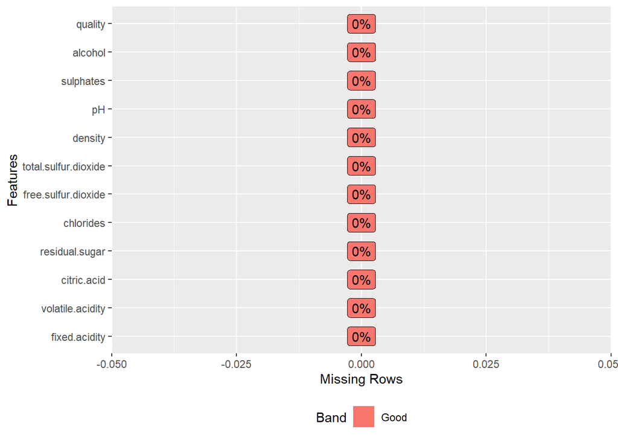

```r
plot_missing(data_wine)
```

It is good that there is no missing value in this dataset.

### Correlation

Check correlation between values:

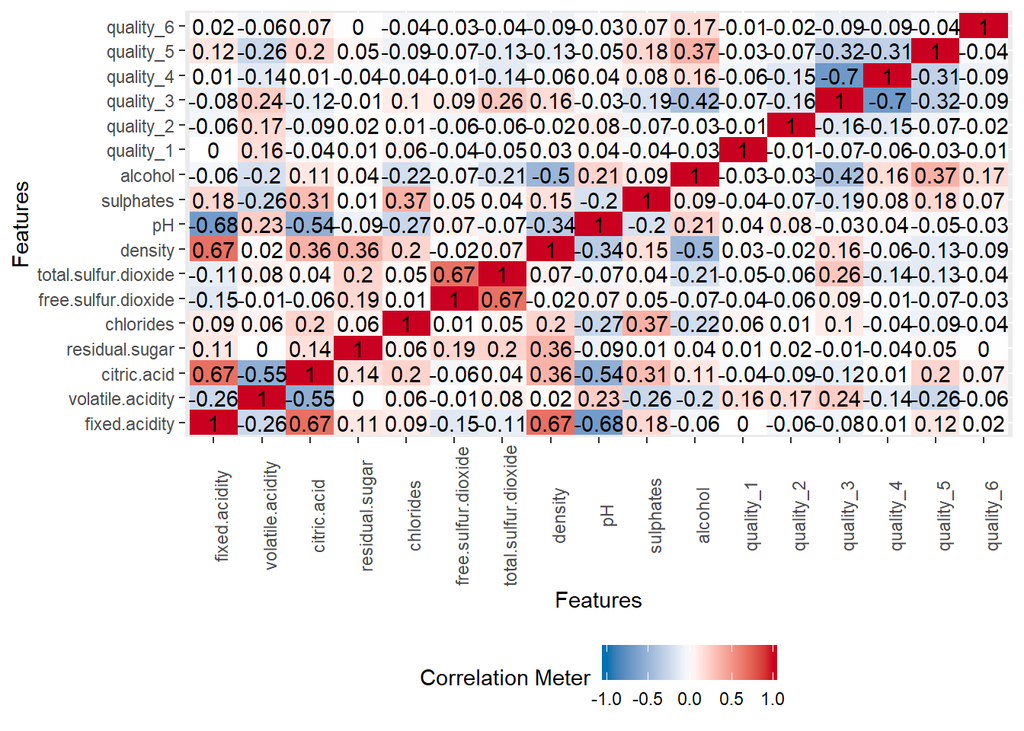

```r
plot_correlation(data_wine)
```

volatile.acidity, citric.acid, total.sulfur.dioxide and alcohol so a good corelation to the target variable

### Variable distributed

Distributed of the independent variables:

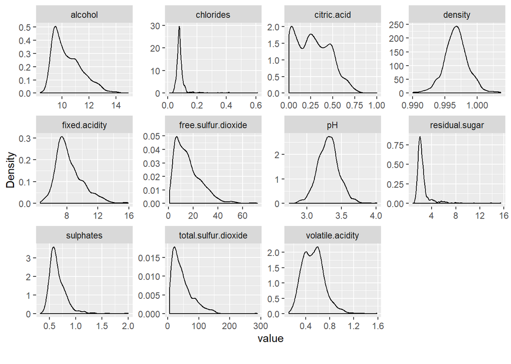

```r
plot_density(data_wine)
```

Only density and pH variable show a normal distribution.  
Distributed of the target variable:

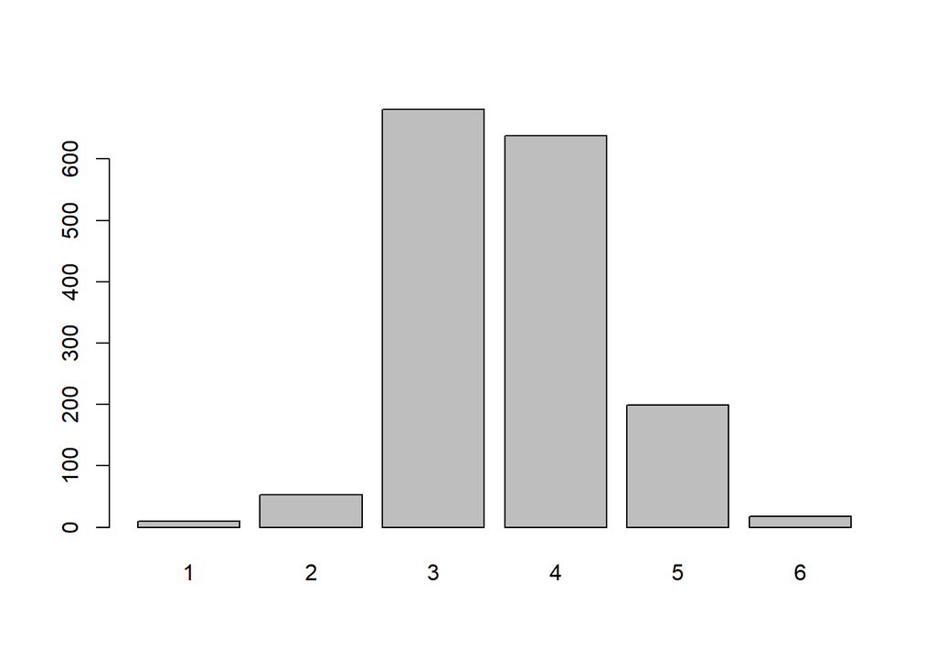

```r
barplot(table(data_wine$quality))
```

```r
table(data_wine$quality)
```

```
##
##   1   2   3   4   5   6
##  10  53 681 638 199  18
```

The target variable show an imbalance issue.

### Stratified sampling

Staified sampling will keep the rate of each category same in training set and test set. The split ration is 0.7 which mean 70% of the observations will belong to training set and 30% will belong to test set.

```r
set.seed(1234)
split = sample.split(data_wine$quality, SplitRatio = 0.7)
training_set = subset(data_wine, split == TRUE)
test_set = subset(data_wine, split == FALSE)
```

The proportion after stratified sampling:

```r
prop.table(table(training_set$quality))
```

```
##
##          1          2          3          4          5          6
## 0.00625000 0.03303571 0.42589286 0.39910714 0.12410714 0.01160714
```

```r
prop.table(table(test_set$quality))
```

```
##
##           1           2           3           4           5           6
## 0.006263048 0.033402923 0.425887265 0.398747390 0.125260960 0.010438413
```

### Training with Naive Bayes model

```r
classifier = naive_bayes(x = training_set[ ,-12], y = training_set$quality )
classifier
```

```
##
## ================================== Naive Bayes ==================================
##
##  Call:
## naive_bayes.default(x = training_set[, -12], y = training_set$quality)
##
## ---------------------------------------------------------------------------------
##
## Laplace smoothing: 0
##
## ---------------------------------------------------------------------------------
##
##  A priori probabilities:
##
##          1          2          3          4          5          6
## 0.00625000 0.03303571 0.42589286 0.39910714 0.12410714 0.01160714
##
## ---------------------------------------------------------------------------------
##
##  Tables:
##
## ---------------------------------------------------------------------------------
##  ::: fixed.acidity (Gaussian)
## ---------------------------------------------------------------------------------
##
## fixed.acidity        1        2        3        4        5        6
##          mean 8.471429 7.572973 8.119287 8.335570 8.788489 8.738462
##          sd   1.823654 1.662436 1.547051 1.816112 2.123986 2.277988
##
## ---------------------------------------------------------------------------------
##  ::: volatile.acidity (Gaussian)
## ---------------------------------------------------------------------------------
##
## volatile.acidity         1         2         3         4         5         6
##             mean 0.9592857 0.7213514 0.5759539 0.4996309 0.4116187 0.4076923
##             sd   0.3525908 0.2134168 0.1664312 0.1658154 0.1490018 0.1589106
##
## ---------------------------------------------------------------------------------
##  ::: citric.acid (Gaussian)
## ---------------------------------------------------------------------------------
```

[output cut: 11 more lines]

```
##           sd   0.9040254 2.0348429 1.2739577 1.3118060 1.4864027 1.0135619
##
## ---------------------------------------------------------------------------------
##  ::: chlorides (Gaussian)
## ---------------------------------------------------------------------------------
##
## chlorides          1          2          3          4          5          6
##      mean 0.10442857 0.08151351 0.09161426 0.08370694 0.07378417 0.06946154
##      sd   0.04861021 0.02628331 0.04801613 0.03785341 0.01916472 0.01158746
##
## ---------------------------------------------------------------------------------
##
## # ... and 6 more tables
##
## ---------------------------------------------------------------------------------
```

The summary of the classifier show the mean and standard deviation of each independent variable on each target variable’s category.

### Prediction

Predict on training dataset:

```r
y_pred_train = predict(classifier, newdata = training_set[ ,-12])
```

Prediction performance on the training set:

```r
# Confusion Matrix
confusionMatrix(y_pred_train, training_set$quality)
```

```
## Confusion Matrix and Statistics
##
##           Reference
## Prediction   1   2   3   4   5   6
##          1   1   1   2   0   0   0
##          2   3  12  20  24   3   0
##          3   2  14 327 128   6   1
##          4   1   9 108 229  55   3
##          5   0   1  19  63  73   7
##          6   0   0   1   3   2   2
##
## Overall Statistics
##
##                Accuracy : 0.575
##                  95% CI : (0.5454, 0.6042)
##     No Information Rate : 0.4259
##     P-Value [Acc > NIR] : < 2.2e-16
##
##                   Kappa : 0.3501
##
##  Mcnemar's Test P-Value : NA
##
## Statistics by Class:
##
##                       Class: 1 Class: 2 Class: 3 Class: 4 Class: 5 Class: 6
## Sensitivity          0.1428571  0.32432   0.6855   0.5123  0.52518 0.153846
## Specificity          0.9973046  0.95383   0.7652   0.7385  0.90826 0.994580
## Pos Pred Value       0.2500000  0.19355   0.6841   0.5654  0.44785 0.250000
## Neg Pred Value       0.9946237  0.97637   0.7664   0.6951  0.93103 0.990108
## Prevalence           0.0062500  0.03304   0.4259   0.3991  0.12411 0.011607
## Detection Rate       0.0008929  0.01071   0.2920   0.2045  0.06518 0.001786
## Detection Prevalence 0.0035714  0.05536   0.4268   0.3616  0.14554 0.007143
## Balanced Accuracy    0.5700809  0.63908   0.7253   0.6254  0.71672 0.574213
```

Prediction performance on test dataset:

```r
y_pred_train_2 = predict(classifier, newdata = test_set[ ,-12])
# Confusion Matrix
confusionMatrix(y_pred_train_2, test_set$quality)
```

```
## Confusion Matrix and Statistics
##
##           Reference
## Prediction   1   2   3   4   5   6
##          1   0   0   2   0   0   0
##          2   1   3   7   7   1   0
##          3   2   8 126  57   7   0
##          4   0   4  62 101  25   1
##          5   0   0   6  25  25   4
##          6   0   1   1   1   2   0
##
## Overall Statistics
##
##                Accuracy : 0.5324
##                  95% CI : (0.4866, 0.5778)
##     No Information Rate : 0.4259
##     P-Value [Acc > NIR] : 1.774e-06
##
##                   Kappa : 0.2743
##
##  Mcnemar's Test P-Value : NA
##
## Statistics by Class:
##
##                      Class: 1 Class: 2 Class: 3 Class: 4 Class: 5 Class: 6
## Sensitivity          0.000000 0.187500   0.6176   0.5288  0.41667  0.00000
## Specificity          0.995798 0.965443   0.7309   0.6806  0.91647  0.98945
## Pos Pred Value       0.000000 0.157895   0.6300   0.5233  0.41667  0.00000
## Neg Pred Value       0.993711 0.971739   0.7204   0.6853  0.91647  0.98945
## Prevalence           0.006263 0.033403   0.4259   0.3987  0.12526  0.01044
## Detection Rate       0.000000 0.006263   0.2630   0.2109  0.05219  0.00000
## Detection Prevalence 0.004175 0.039666   0.4175   0.4029  0.12526  0.01044
## Balanced Accuracy    0.497899 0.576471   0.6743   0.6047  0.66657  0.49473
```

### Handle imbalance issue with Over-sampling

The observation of the minority classes will be random over-sampling by using the upSample fuction in Caret Packet

```r
set.seed(2969)
data_wine_eq <- upSample(x = data_wine[, -12], y = data_wine$quality)
```

Structure of the new dataset:

```r
str(data_wine_eq)
```

```
## 'data.frame':    4086 obs. of  12 variables:
##  $ fixed.acidity       : num  11.6 10.4 7.4 10.4 8.3 7.6 6.8 7.3 7.1 6.7 ...
##  $ volatile.acidity    : num  0.58 0.61 1.18 0.44 1.02 ...
##  $ citric.acid         : num  0.66 0.49 0 0.42 0.02 0 0 0.05 0.05 0.02 ...
##  $ residual.sugar      : num  2.2 2.1 4.25 1.5 3.4 2.1 1.2 2.1 5.7 1.8 ...
##  $ chlorides           : num  0.074 0.2 0.097 0.145 0.084 0.137 0.267 0.061 0.082 0.078 ...
##  $ free.sulfur.dioxide : num  10 5 5 34 6 5 16 20 3 6 ...
##  $ total.sulfur.dioxide: num  47 16 14 48 11 9 29 49 14 12 ...
##  $ density             : num  1.001 0.999 0.997 0.998 0.999 ...
##  $ pH                  : num  3.25 3.16 3.63 3.38 3.48 3.5 3.32 3.31 3.4 3.55 ...
##  $ sulphates           : num  0.57 0.63 0.54 0.86 0.49 0.4 0.51 0.55 0.52 0.63 ...
##  $ alcohol             : num  9 8.4 10.7 9.9 11 10.9 9.8 9.7 10.2 9.95 ...
##  $ Class               : Factor w/ 6 levels "1","2","3","4",..: 1 1 1 1 1 1 1 1 1 1 ...
```

Distribution of the target variable:

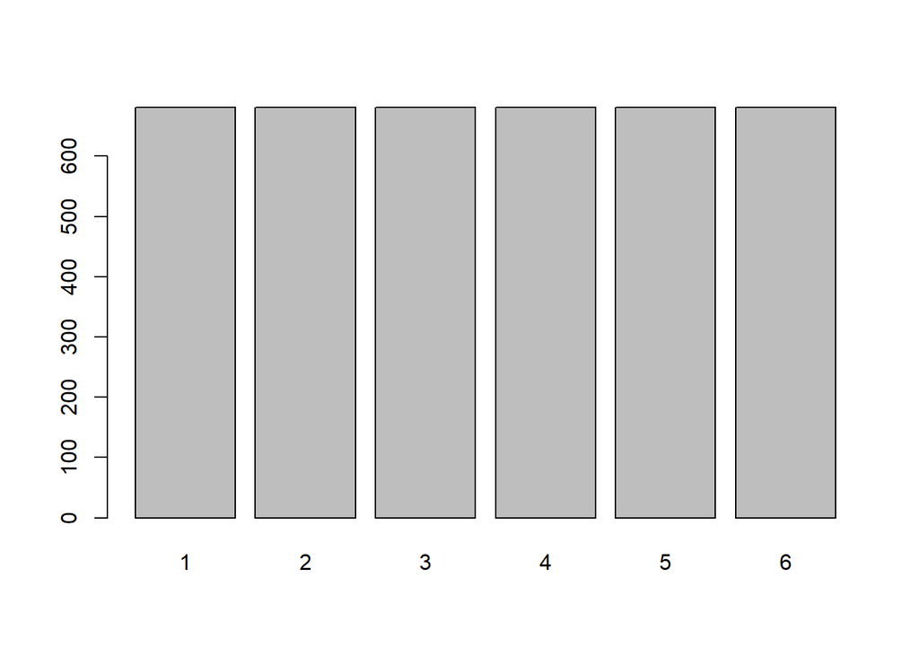

```r
barplot(table(data_wine_eq$Class))
```

### Stratified sampling the balanced dataset

```r
set.seed(1234)
split = sample.split(data_wine_eq$Class, SplitRatio = 0.7)
training_set_eq = subset(data_wine_eq, split == TRUE)
test_set_eq = subset(data_wine_eq, split == FALSE)
```

The proportion after stratified sampling:

```r
prop.table(table(training_set_eq$Class))
```

```
##
##         1         2         3         4         5         6
## 0.1666667 0.1666667 0.1666667 0.1666667 0.1666667 0.1666667
```

```r
prop.table(table(test_set_eq$Class))
```

```
##
##         1         2         3         4         5         6
## 0.1666667 0.1666667 0.1666667 0.1666667 0.1666667 0.1666667
```

### Training the balanced dataset with Naive Bayes model

```r
classifier_eq = naive_bayes(x = training_set_eq[ ,-12], y = training_set_eq$Class )
classifier_eq
```

```
##
## ================================== Naive Bayes ==================================
##
##  Call:
## naive_bayes.default(x = training_set_eq[, -12], y = training_set_eq$Class)
##
## ---------------------------------------------------------------------------------
##
## Laplace smoothing: 0
##
## ---------------------------------------------------------------------------------
##
##  A priori probabilities:
##
##         1         2         3         4         5         6
## 0.1666667 0.1666667 0.1666667 0.1666667 0.1666667 0.1666667
##
## ---------------------------------------------------------------------------------
##
##  Tables:
##
## ---------------------------------------------------------------------------------
##  ::: fixed.acidity (Gaussian)
## ---------------------------------------------------------------------------------
##
## fixed.acidity        1        2        3        4        5        6
##          mean 8.255136 7.775472 8.185115 8.346541 9.012579 8.639832
##          sd   1.633692 1.584234 1.571011 1.754542 1.989756 1.958671
##
## ---------------------------------------------------------------------------------
##  ::: volatile.acidity (Gaussian)
## ---------------------------------------------------------------------------------
##
## volatile.acidity         1         2         3         4         5         6
##             mean 0.8972327 0.6918763 0.5746960 0.5018553 0.4043711 0.4122642
##             sd   0.3131629 0.2147771 0.1637445 0.1603855 0.1481685 0.1330363
##
## ---------------------------------------------------------------------------------
##  ::: citric.acid (Gaussian)
## ---------------------------------------------------------------------------------
```

[output cut: 11 more lines]

```
##           sd   1.319437 1.804940 1.282623 1.598613 1.280935 1.253331
##
## ---------------------------------------------------------------------------------
##  ::: chlorides (Gaussian)
## ---------------------------------------------------------------------------------
##
## chlorides          1          2          3          4          5          6
##      mean 0.11808595 0.09202306 0.09138155 0.08562893 0.07722013 0.06954298
##      sd   0.05940891 0.07903061 0.05114205 0.03915830 0.03044495 0.01072267
##
## ---------------------------------------------------------------------------------
##
## # ... and 6 more tables
##
## ---------------------------------------------------------------------------------
```

### Prediction on balanced dataset

Prediction performance on balanced training dataset:

```r
y_pred_train_eq = predict(classifier_eq, newdata = training_set_eq[ ,-12])
# Confusion Matrix
confusionMatrix(y_pred_train_eq, training_set_eq$Class)
```

```
## Confusion Matrix and Statistics
##
##           Reference
## Prediction   1   2   3   4   5   6
##          1 392 186  81  50  12   0
##          2   0  88  36  27  18   0
##          3  43 118 249 108  16   0
##          4  42  51  56 114  56  20
##          5   0  25  36  99 153   0
##          6   0   9  19  79 222 457
##
## Overall Statistics
##
##                Accuracy : 0.5077
##                  95% CI : (0.4892, 0.5262)
##     No Information Rate : 0.1667
##     P-Value [Acc > NIR] : < 2.2e-16
##
##                   Kappa : 0.4092
##
##  Mcnemar's Test P-Value : NA
##
## Statistics by Class:
##
##                      Class: 1 Class: 2 Class: 3 Class: 4 Class: 5 Class: 6
## Sensitivity            0.8218  0.18449   0.5220  0.23899  0.32075   0.9581
## Specificity            0.8621  0.96604   0.8805  0.90566  0.93291   0.8621
## Pos Pred Value         0.5437  0.52071   0.4663  0.33628  0.48882   0.5814
## Neg Pred Value         0.9603  0.85555   0.9021  0.85612  0.87289   0.9904
## Prevalence             0.1667  0.16667   0.1667  0.16667  0.16667   0.1667
## Detection Rate         0.1370  0.03075   0.0870  0.03983  0.05346   0.1597
## Detection Prevalence   0.2519  0.05905   0.1866  0.11845  0.10936   0.2746
## Balanced Accuracy      0.8419  0.57526   0.7013  0.57233  0.62683   0.9101
```

Prediction performance on balanced test dataset:

```r
y_pred_train_eq_2 = predict(classifier_eq, newdata = test_set_eq[ ,-12])
# Confusion Matrix
confusionMatrix(y_pred_train_eq_2, test_set_eq$Class)
```

```
## Confusion Matrix and Statistics
##
##           Reference
## Prediction   1   2   3   4   5   6
##          1 166  87  36  16   9   0
##          2   0  32  18  14   5   0
##          3  19  42 104  42   9   0
##          4  19  23  23  42  17  13
##          5   0  14  16  44  67   0
##          6   0   6   7  46  97 191
##
## Overall Statistics
##
##                Accuracy : 0.4918
##                  95% CI : (0.4635, 0.5202)
##     No Information Rate : 0.1667
##     P-Value [Acc > NIR] : < 2.2e-16
##
##                   Kappa : 0.3902
##
##  Mcnemar's Test P-Value : NA
##
## Statistics by Class:
##
##                      Class: 1 Class: 2 Class: 3 Class: 4 Class: 5 Class: 6
## Sensitivity            0.8137  0.15686  0.50980  0.20588  0.32843   0.9363
## Specificity            0.8549  0.96373  0.89020  0.90686  0.92745   0.8471
## Pos Pred Value         0.5287  0.46377  0.48148  0.30657  0.47518   0.5504
## Neg Pred Value         0.9582  0.85108  0.90079  0.85097  0.87350   0.9852
## Prevalence             0.1667  0.16667  0.16667  0.16667  0.16667   0.1667
## Detection Rate         0.1356  0.02614  0.08497  0.03431  0.05474   0.1560
## Detection Prevalence   0.2565  0.05637  0.17647  0.11193  0.11520   0.2835
## Balanced Accuracy      0.8343  0.56029  0.70000  0.55637  0.62794   0.8917
```

Accuracy is reduced to 0.5077 on balanced training set and 0.4918 on balanced test set. On the positive view, the kappa index on the balanced test set increase to 0.3902 but still fair. The sensitivity of Class 1 and Class 6 show greate promise at 0.8137 and 0.9363 which mean there 2 classes have unique feature and can be clearly discriminated.

### Training the balanced dataset with Kernel density Naive Bayes model

Most of the independent variables are Non-normal distribution, on the last effort, the balanced training set will be trained by Kernel density Naive Bayes model to enhance the accuracy and better handdle Non-normal distribution data.

```r
classifier_kd = naive_bayes(x = training_set_eq[ ,-12], y = training_set_eq$Class, usekernel = TRUE )
classifier_kd
```

```
##
## ================================== Naive Bayes ==================================
##
##  Call:
## naive_bayes.default(x = training_set_eq[, -12], y = training_set_eq$Class,
##     usekernel = TRUE)
##
## ---------------------------------------------------------------------------------
##
## Laplace smoothing: 0
##
## ---------------------------------------------------------------------------------
##
##  A priori probabilities:
##
##         1         2         3         4         5         6
## 0.1666667 0.1666667 0.1666667 0.1666667 0.1666667 0.1666667
##
## ---------------------------------------------------------------------------------
##
##  Tables:
##
## ---------------------------------------------------------------------------------
##  ::: fixed.acidity::1 (KDE)
## ---------------------------------------------------------------------------------
##
## Call:
##  density.default(x = x, na.rm = TRUE)
##
## Data: x (477 obs.);  Bandwidth 'bw' = 0.4283
##
##        x                y
##  Min.   : 5.415   Min.   :0.0009235
##  1st Qu.: 7.283   1st Qu.:0.0336489
##  Median : 9.150   Median :0.0861106
##  Mean   : 9.150   Mean   :0.1337000
##  3rd Qu.:11.017   3rd Qu.:0.1712641
##  Max.   :12.885   Max.   :0.4414961
##
## ---------------------------------------------------------------------------------
```

[output cut: 482 more lines]

```
## Data: x (477 obs.);  Bandwidth 'bw' = 0.002543
##
##        x                 y
##  Min.   :0.03637   Min.   : 0.08694
##  1st Qu.:0.05069   1st Qu.: 4.40730
##  Median :0.06500   Median :13.90866
##  Mean   :0.06500   Mean   :17.44511
##  3rd Qu.:0.07931   3rd Qu.:26.30418
##  Max.   :0.09363   Max.   :49.90354
##
## ---------------------------------------------------------------------------------
##
## # ... and 6 more tables
##
## ---------------------------------------------------------------------------------
```

### Prediction with Kernel density Naive Bayes model

Prediction performance on balanced training dataset:

```r
y_pred_train_kd = predict(classifier_kd, newdata = training_set_eq[ ,-12])
# Confusion Matrix
confusionMatrix(y_pred_train_kd, training_set_eq$Class)
```

```
## Confusion Matrix and Statistics
##
##           Reference
## Prediction   1   2   3   4   5   6
##          1 477  73  22  16   5   0
##          2   0 308  76  44  21   0
##          3   0  69 297 107   7   0
##          4   0  21  43 174  58   0
##          5   0   6  30 110 326  17
##          6   0   0   9  26  60 460
##
## Overall Statistics
##
##                Accuracy : 0.7135
##                  95% CI : (0.6965, 0.73)
##     No Information Rate : 0.1667
##     P-Value [Acc > NIR] : < 2.2e-16
##
##                   Kappa : 0.6562
##
##  Mcnemar's Test P-Value : NA
##
## Statistics by Class:
##
##                      Class: 1 Class: 2 Class: 3 Class: 4 Class: 5 Class: 6
## Sensitivity            1.0000   0.6457   0.6226   0.3648   0.6834   0.9644
## Specificity            0.9514   0.9409   0.9233   0.9488   0.9317   0.9602
## Pos Pred Value         0.8044   0.6860   0.6188   0.5878   0.6667   0.8288
## Neg Pred Value         1.0000   0.9300   0.9244   0.8819   0.9364   0.9926
## Prevalence             0.1667   0.1667   0.1667   0.1667   0.1667   0.1667
## Detection Rate         0.1667   0.1076   0.1038   0.0608   0.1139   0.1607
## Detection Prevalence   0.2072   0.1569   0.1677   0.1034   0.1709   0.1939
## Balanced Accuracy      0.9757   0.7933   0.7730   0.6568   0.8075   0.9623
```

Prediction performance on balanced test dataset:

```r
y_pred_train_kd_2 = predict(classifier_kd, newdata = test_set_eq[ ,-12])
# Confusion Matrix
confusionMatrix(y_pred_train_kd_2, test_set_eq$Class)
```

```
## Confusion Matrix and Statistics
##
##           Reference
## Prediction   1   2   3   4   5   6
##          1 204  36  12   4   4   0
##          2   0 117  27  27  11   0
##          3   0  30 121  51   1   0
##          4   0  12  26  52  20   0
##          5   0   9  14  53 143   9
##          6   0   0   4  17  25 195
##
## Overall Statistics
##
##                Accuracy : 0.6797
##                  95% CI : (0.6528, 0.7058)
##     No Information Rate : 0.1667
##     P-Value [Acc > NIR] : < 2.2e-16
##
##                   Kappa : 0.6157
##
##  Mcnemar's Test P-Value : NA
##
## Statistics by Class:
##
##                      Class: 1 Class: 2 Class: 3 Class: 4 Class: 5 Class: 6
## Sensitivity            1.0000  0.57353  0.59314  0.25490   0.7010   0.9559
## Specificity            0.9451  0.93627  0.91961  0.94314   0.9167   0.9549
## Pos Pred Value         0.7846  0.64286  0.59606  0.47273   0.6272   0.8091
## Neg Pred Value         1.0000  0.91651  0.91871  0.86355   0.9388   0.9908
## Prevalence             0.1667  0.16667  0.16667  0.16667   0.1667   0.1667
## Detection Rate         0.1667  0.09559  0.09886  0.04248   0.1168   0.1593
## Detection Prevalence   0.2124  0.14869  0.16585  0.08987   0.1863   0.1969
## Balanced Accuracy      0.9725  0.75490  0.75637  0.59902   0.8088   0.9554
```

The accurrcy soares into 0.7135 on balanced training set and 0.6797 on balanced test set far better than the last 2 models. Kappa also raises to 0.6157 on balanced test set which is substantial. The sensitivity of the class 5 is achieved 0.7010 on balanced test set, which makes the sentisitvity of 3/6 in the good rate, class 4 is still stay at 0.25490 very poor sensitivity, refer to the confusion matrix, most of the observations in class 4 be wrongly classified as class 3 (51 observations) and class 5(53 observations).

### Conclusion

By the way training with Kernel density Naive Bayes model and dataset with imbalance issue handled, the accuracy and kappa reach the highest. But in there, class 4 of the target variable still has low sensitivity - 0.255, which mean only 25.5% of the truly class 4 observations are correctly identified.